```r
library(ggplot2)
library(mgcv)
library(dplyr)
library(readxl)
```

Читаем данные

```r
finch_il <- read_excel("Data/Spinus_2020_parasitemia_IL6_survival_final.xlsx", na = "NA", sheet = "Spinus_2020_parasitemia_IL6_sur")
finch_il$Experiment <- factor(finch_il$Experiment)
finch_il$Ring <- factor(finch_il$Ring)

n_obs_il <- finch_il %>% group_by(Ring) %>% summarise(N_il_obs = n())


finch <- read_excel("Data/Spinus_2020_parasitemia_IL6_survival_final.xlsx", na = "NA", sheet = "RMR")
finch_il$Experiment <- factor(finch_il$Experiment)
finch_il$Ring <- factor(finch_il$Ring)

# n_obs_rmr <- finch %>% group_by(Ring) %>% summarise(N_rmr_obs = n())
#
# n_obs <- merge(n_obs_il, n_obs_rmr, by = "Ring")
```

## Замечания по структуре материала

Если я правильно понял, то измерение RMR, т.е. величины, находящейся в фокусе исследования, проводилось без сопряжения по времени с измерениями паразитимии и анализом интерлейкинов. Это означает, что однозначного соответствия между датой измерений RMR датой измерения двух других показателей нет. В этой ситуации можно пойти двумя путями.

1. В качестве данных, описывающих состояние птицы, брать среднее значение паразитемии и концентрации интерлейкинов, измеренные в ближайшую дату до и после измерения RMR.
2. В качестве данных, описывающих состояние птицы, брать данные по паразитемии и концентрации интерлейкинов, измеренные 2a) непосредственно перед (в ближайшую дату) измерением RMR или 2b) сразу после (в ближайшую дату) измерения RMR.

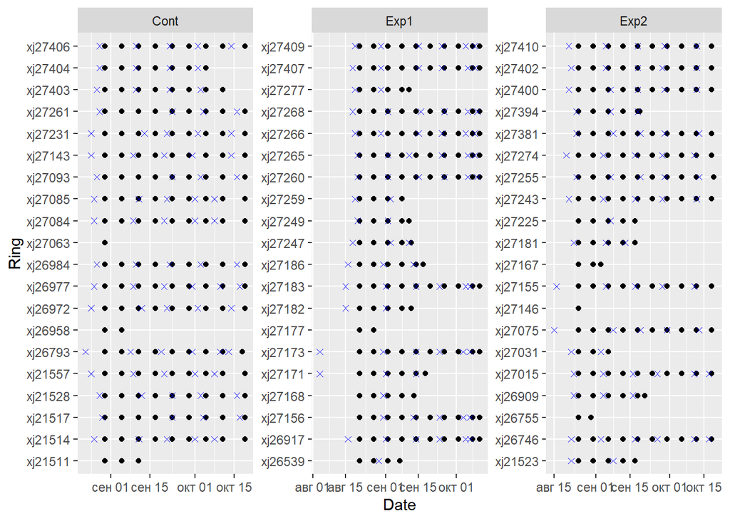

```r
ggplot(finch_il, aes(x = Date, y = Ring)) +
  geom_point() +
  facet_wrap(~Experiment, scales = "free") +
  geom_point(data = finch,  color = "blue", shape = 4)
```

Такими образом, в качестве значений предикторов для модели будем использовать, значения паразитемии и интерлейкинов, измеренные в ближайшую дату, следующую за днем измерения RMR.

## Зависимая переменная и предикторы для модели

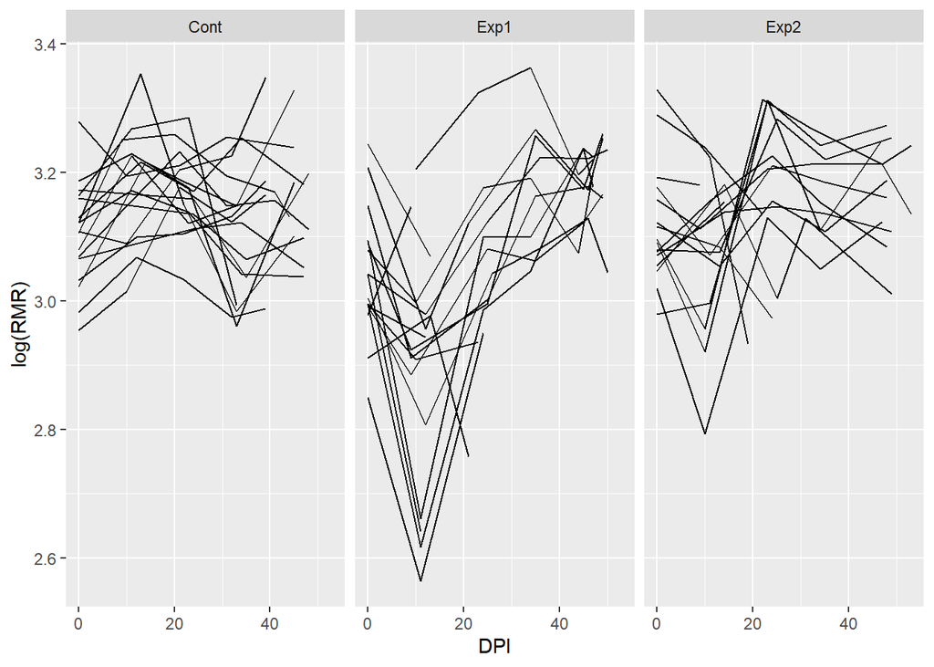

```r
ggplot(finch, aes(x = DPI, y = log(RMR), group = Ring)) + geom_line() + facet_wrap(~Experiment)
```

### Предикторы в модели

1. Группа птиц (Experiment). Здесь все понятно: Дискретный предиктор с тремя уровнями. Базовый уровень “Cont”.
2. Масса птицы (Mass). Это “техническая” ковариата, необходимая для учет того, что птицы разной массы дышат по-разному.
3. Концентрация интерлейкинов (IL). Тут тоже все более или менее понятно.
4. Что-то про парзитемию. Здесь много непонятного. Начнем с того, что паразитемия у разных птиц ведет себя нелинейно. Есть период когда наблюдается острая фаза болезни (пик паразитемии), которая затем проходит. Однако у птиц из группы Exp1 в большинстве случаев паразитемия падает до нуля (птичка излечивается?), в то время как у птиу из группы Exp2, в большинстве случаев падения до нуля не происходило.

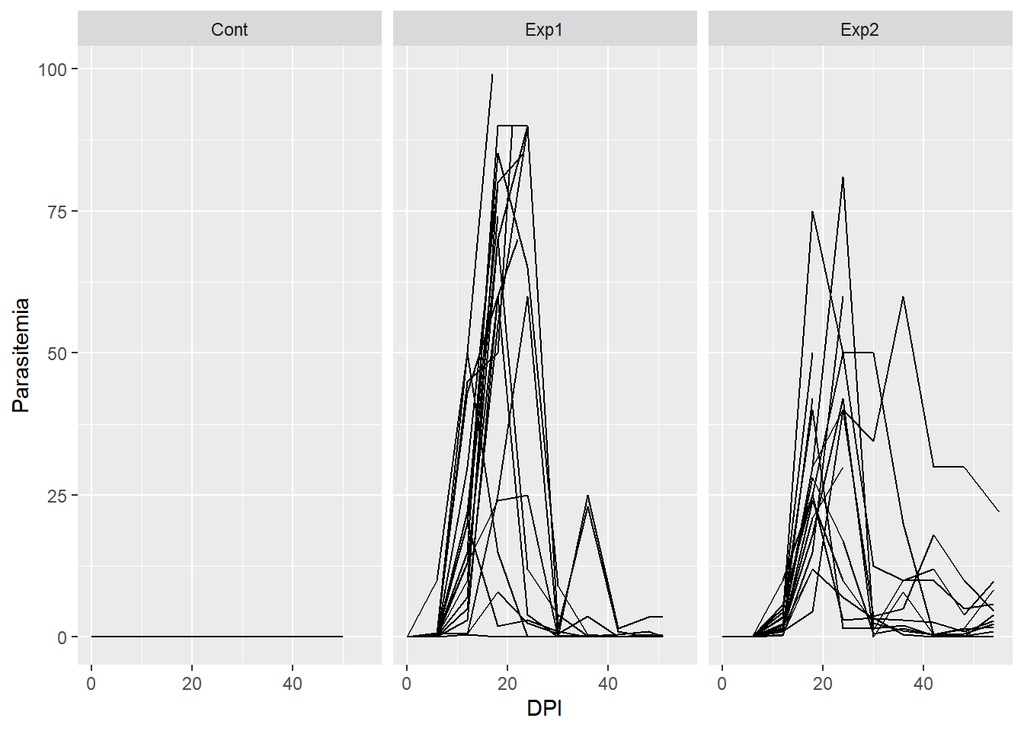

```r
ggplot(finch_il, aes(x = DPI, y = Parasitemia, group = Ring)) + geom_line() + facet_wrap(~Experiment)
```

В связи с этим, предлагаю в качестве предиктора брать величину, описывающую накопленную к дате измерения паразитемию. Эта величина ведет себя следующим образом.

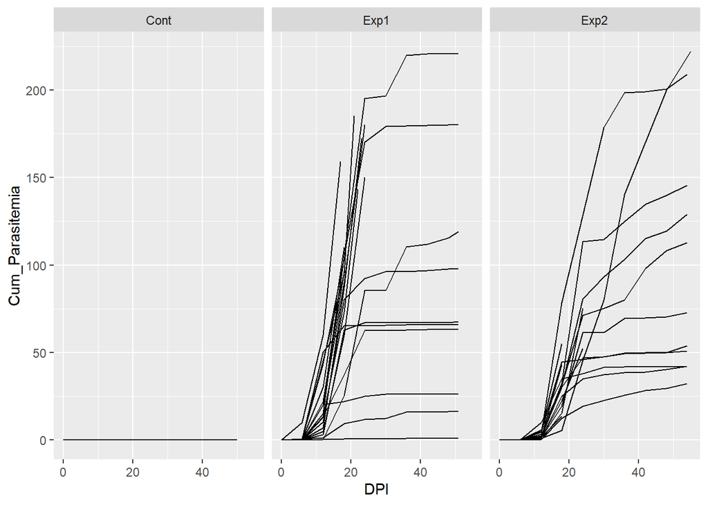

```r
finch_il <- finch_il %>% group_by(Ring) %>% arrange(Date) %>% mutate(Cum_Parasitemia = cumsum(Parasitemia), Cum_IL = cumsum(IL6_pg_ml)) %>% arrange(Ring, Date)


ggplot(finch_il, aes(x = DPI, y = Cum_Parasitemia, group = Ring)) + geom_line() + facet_wrap(~Experiment)
```

Очевидно, что выход накопленной паразитемии на плато означает, что острая фаза болезни прошла. Видно, что у птиц из группы Exp1 такой выход на плато происходит, а у птиц из группы Exp2 - нет.

**Важно!** Накопленная паразитемия, таким образом, одновременно включает информацию и о продолжительности болезни (DPI), и о ее интенсивности (количество паразитов).

```r
# Код для совмещения данных по RMR и измерениям паразитемии и интерлейкинов
finch$Parasitemia <- NA
finch$IL <- NA
finch$Cum_Parasitemia <- NA
finch$Dif_Date <- NA
finch$Survival <- NA

for(i in 1:nrow(finch)){
  df <- finch_il %>% filter(Ring == finch$Ring[i])

  dif_dat1 <- (difftime(df$Date, finch$Date[i]))
  dif_dat1[dif_dat1 < 0 ] <- NA
  time1 <- df$Date[which.min(dif_dat1)]

  finch$Parasitemia[i] <- df$Parasitemia[df$Date == time1]
  finch$IL[i] <- df$IL6_pg_ml[df$Date == time1]
  finch$Cum_Parasitemia[i] <- df$Cum_Parasitemia[df$Date == time1]
  finch$Survival[i] <- df$Survival[df$Date == time1]

  finch$Dif_Date[i] <- as.numeric(difftime(time1, finch$Date[i], units = "day"))
}
```

## Модель

```r
finch$Experiment <- factor(finch$Experiment)
finch$Ring <- factor(finch$Ring)
finch$Survival <- factor(finch$Survival)


M1_gam <- gam(log(RMR) ~ s(Cum_Parasitemia, by = Experiment)  + s(IL, by = Experiment) + Experiment + log(Mass)  + s(Ring, k = 53, bs = "re"),  method = "REML", data = finch)
```

Вот ее параметры

```r
summary(M1_gam)
```

```
##
## Family: gaussian
## Link function: identity
##
## Formula:
## log(RMR) ~ s(Cum_Parasitemia, by = Experiment) + s(IL, by = Experiment) +
##     Experiment + log(Mass) + s(Ring, k = 53, bs = "re")
##
## Parametric coefficients:
##                Estimate Std. Error t value Pr(>|t|)
## (Intercept)     1.92262    0.31920   6.023 9.63e-09 ***
## ExperimentExp1 -0.10746    0.13161  -0.817    0.415
## ExperimentExp2 -0.04748    0.13250  -0.358    0.721
## log(Mass)       0.47851    0.11427   4.188 4.44e-05 ***
## ---
## Signif. codes:  0 '***' 0.001 '**' 0.01 '*' 0.05 '.' 0.1 ' ' 1
##
## Approximate significance of smooth terms:
##                                         edf    Ref.df      F  p-value
## s(Cum_Parasitemia):ExperimentCont 1.707e-15 1.707e-15  0.000  1.00000
## s(Cum_Parasitemia):ExperimentExp1 1.000e+00 1.000e+00 19.619 1.71e-05 ***
## s(Cum_Parasitemia):ExperimentExp2 2.375e+00 2.852e+00  6.939  0.00042 ***
## s(IL):ExperimentCont              1.000e+00 1.000e+00  0.024  0.87744
## s(IL):ExperimentExp1              2.767e+00 3.357e+00  7.838 3.56e-05 ***
## s(IL):ExperimentExp2              1.000e+00 1.000e+00  5.010  0.02645 *
## s(Ring)                           3.160e+01 5.000e+01  1.851  < 2e-16 ***
## ---
## Signif. codes:  0 '***' 0.001 '**' 0.01 '*' 0.05 '.' 0.1 ' ' 1
##
## Rank: 110/111
## R-sq.(adj) =  0.503   Deviance explained =   60%
## -REML = -161.1  Scale est. = 0.0081861  n = 221
```

Диагностика

```
##
## Method: REML   Optimizer: outer newton
## full convergence after 12 iterations.
## Gradient range [-4.458394e-05,9.482132e-05]
## (score -161.1028 & scale 0.008186143).
## Hessian positive definite, eigenvalue range [2.664535e-15,108.0486].
## Model rank =  110 / 111
##
## Basis dimension (k) checking results. Low p-value (k-index<1) may
## indicate that k is too low, especially if edf is close to k'.
##
##                                         k'      edf k-index p-value
## s(Cum_Parasitemia):ExperimentCont 9.00e+00 1.71e-15    0.89   0.025 *
## s(Cum_Parasitemia):ExperimentExp1 9.00e+00 1.00e+00    0.89   0.040 *
## s(Cum_Parasitemia):ExperimentExp2 9.00e+00 2.37e+00    0.89   0.055 .
## s(IL):ExperimentCont              9.00e+00 1.00e+00    1.00   0.530
## s(IL):ExperimentExp1              9.00e+00 2.77e+00    1.00   0.445
## s(IL):ExperimentExp2              9.00e+00 1.00e+00    1.00   0.455
## s(Ring)                           5.30e+01 3.16e+01      NA      NA
## ---
## Signif. codes:  0 '***' 0.001 '**' 0.01 '*' 0.05 '.' 0.1 ' ' 1
```

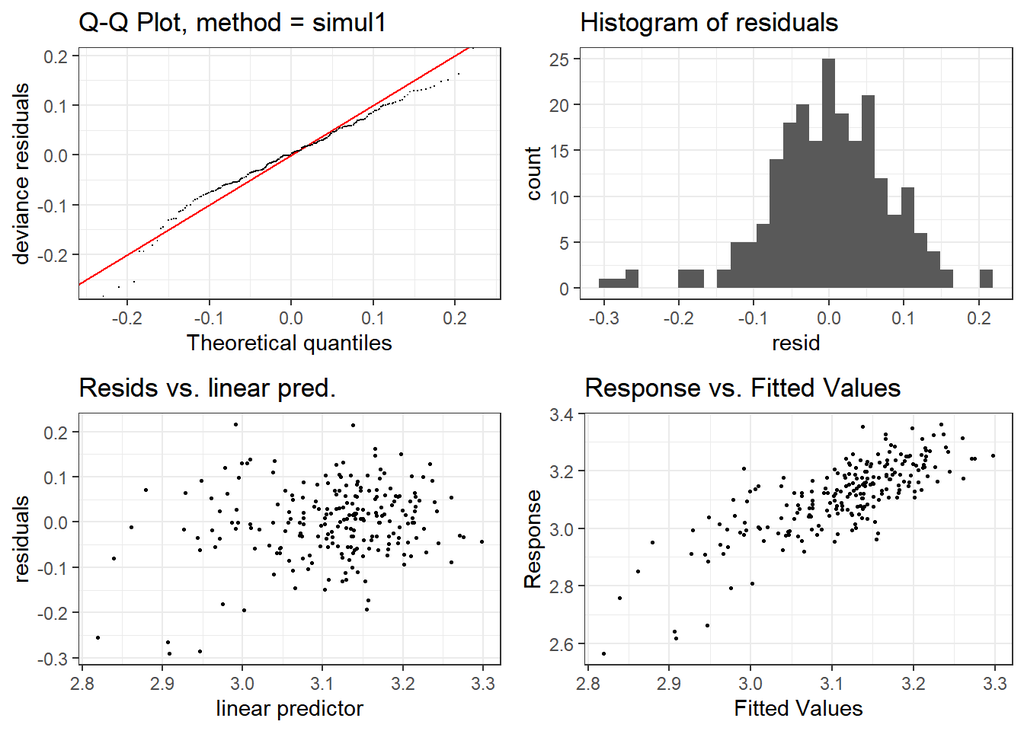

```r
library(mgcViz)
b <- getViz(M1_gam)
check.gamViz(b)
```

Особых проблем не вижу.

## Визуализации модели

```r
library(gratia)
library(cowplot)


Pl_Cum_Paras_Exp1 <- draw(M1_gam, select = c(2), scales = "fixed") + geom_hline(yintercept = 0)

Pl_Cum_Paras_Exp2 <- draw(M1_gam, select = c(3), scales = "fixed") + geom_hline(yintercept = 0)
```

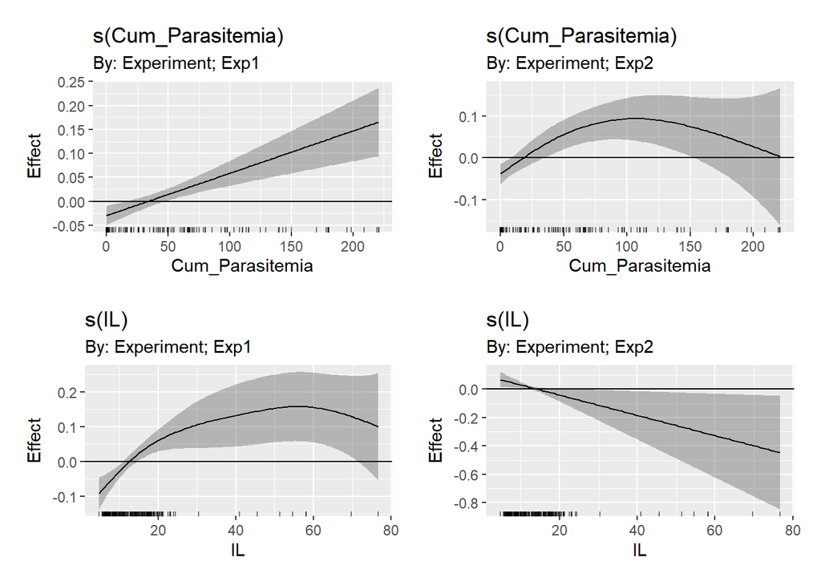

```r
Pl_IL_Exp1 <- draw(M1_gam, select = c(5), scales = "fixed") + geom_hline(yintercept = 0)

Pl_IL_Exp2 <- draw(M1_gam, select = c(6), scales = "fixed") + geom_hline(yintercept = 0)

library(patchwork)
plot_grid(Pl_Cum_Paras_Exp1, Pl_Cum_Paras_Exp2, nrow = 1) / plot_grid(Pl_IL_Exp1, Pl_IL_Exp2, nrow = 1)
```

## Что видно из модели

1. В среднем значимых отличий в RMR у Exp1 и Exp2 от контроля нет.
2. В группе Exp1, по мере накопления паразитемии (продолжительность болезни), линейно увеличивается RMR, в то время как в группе Exp2 на ранних этапах заболевания идет рост RMR, на более поздних этапах болезни рост RMR останавливается или становится отрицательным.
3. Похожие результаты получаются и при анализе связи RMR с конентрацией интерлейкинов. В группе Exp1 по мере развития имунного ответа наблюдается рост RMR, а группе Exp2 RMR по мере развития иммунного ответа падает.

Похоже, что в группе Exp1 заражение малярией увеличивает RMR, а группе Exp2, скорее, уменьшает. Но обе тенденции довольно слабо выражены на фоне варьирования RMR в контроле.